# 05: *Bioconductor* Annotation Resources

Martin Morgan

Roswell Park Comprehensive Cancer Center

July 02, 2019

# 1 Mapping between symbols

## 1.1 org.Hs.eg.db

The `org` packages contain information to map between different symbols. Here check for available `org` packages.

```r
BiocManager::available("^org\\.")
```

```
##  [1] "org.Ag.eg.db"      "org.At.tair.db"    "org.Bt.eg.db"
##  [4] "org.Ce.eg.db"      "org.Cf.eg.db"      "org.Dm.eg.db"
##  [7] "org.Dr.eg.db"      "org.EcK12.eg.db"   "org.EcSakai.eg.db"
## [10] "org.Gg.eg.db"      "org.Hs.eg.db"      "org.Mm.eg.db"
## [13] "org.Mmu.eg.db"     "org.Pf.plasmo.db"  "org.Pt.eg.db"
## [16] "org.Rn.eg.db"      "org.Sc.sgd.db"     "org.Ss.eg.db"
## [19] "org.Xl.eg.db"
```

The regular expression `"^org\\.")` insists that the package names starts with `org` (`"^org"`) followed by a literal period rather than a wild-card representing any letter (`"\\."`).

In addition to these packages, many `org` resources are available from AnnotationHub, described below

```r
library(AnnotationHub)
```

```r
query(AnnotationHub(), "^org\\.")
```

```
## snapshotDate(): 2019-05-02
```

```
## AnnotationHub with 1710 records
## # snapshotDate(): 2019-05-02
## # $dataprovider: ftp://ftp.ncbi.nlm.nih.gov/gene/DATA/
## # $species: Escherichia coli, 'Chlorella vulgaris'_C-169, 'Klebsiella a...
## # $rdataclass: OrgDb
## # additional mcols(): taxonomyid, genome, description,
## #   coordinate_1_based, maintainer, rdatadateadded, preparerclass,
## #   tags, rdatapath, sourceurl, sourcetype
## # retrieve records with, e.g., 'object[["AH70563"]]'
##
##             title
##   AH70563 | org.Ag.eg.db.sqlite
##   AH70564 | org.At.tair.db.sqlite
##   AH70565 | org.Bt.eg.db.sqlite
##   AH70566 | org.Cf.eg.db.sqlite
##   AH70567 | org.Gg.eg.db.sqlite
##   ...       ...
##   AH73812 | org.Plasmodium_vivax.eg.sqlite
##   AH73813 | org.Burkholderia_mallei_ATCC_23344.eg.sqlite
##   AH73814 | org.Bacillus_cereus_(strain_ATCC_14579_|_DSM_31).eg.sqlite
##   AH73815 | org.Bacillus_cereus_ATCC_14579.eg.sqlite
##   AH73816 | org.Schizosaccharomyces_cryophilus_OY26.eg.sqlite
```

The naming convention of `org` objects uses a two-letter code to represent species, e.g., `Hs` is *Homo sapiens* followed by the *central* identifier used to map to and from other symbols; for `org.Hs.eg.db`, the central identifier is the Entrez gene identifier, and to map from, say HGNC Symbol to Ensembl identifier, a map must exist between the gene symbol and the Entrez identifier, and then from the Entrez identifier to the Ensembl identifier.

Many additional `org` packages are available on AnnotationHub, as mentioned briefly below.

```r
library(org.Hs.eg.db)
```

We can discover available `keytypes()` for querying the database, and `columns()` to map to, e.g.,

```r
head(keys(org.Hs.eg.db))
```

```
## [1] "1"  "2"  "3"  "9"  "10" "11"
```

Here are a handful of ENTREZID keys

```r
eid <- sample(keys(org.Hs.eg.db), 10)
```

Two main functions are `select()` and `mapIds()`. `mapIds()` is more focused. It guarantees a one-to-one mapping between keys a single selected column. By defaul, if a key maps to multiple values, then the ‘first’ value returned by the database is used. The return value is a named vector; the 1:1 mapping between query and return value makes this function particularly useful in pipelines where a single mapping must occur.

```r
mapIds(org.Hs.eg.db, eid, "SYMBOL", "ENTREZID")
```

```
##      112268315          54012      106481389          57325           4113
## "LOC112268315"      "ZNF299P"    "RNU6-657P"        "KAT14"       "MAGEB2"
##      100418862      104413892          79160      106481873      105369543
##     "SPECC1P1"      "F10-AS1"    "LINC01711"     "RNU4-84P" "LOC105369543"
```

`select()` is more general, returning a data.frame of keys, plus one or more columns. If a key maps to multiple values, then multiple rows are returned.

```r
map <- select(org.Hs.eg.db, eid, c("SYMBOL", "GO"), "ENTREZID")
dim(map)
```

```
## [1] 17  5
```

```r
head(map)
```

```
##    ENTREZID       SYMBOL         GO EVIDENCE ONTOLOGY
## 1 112268315 LOC112268315       <NA>     <NA>     <NA>
## 2     54012      ZNF299P       <NA>     <NA>     <NA>
## 3 106481389    RNU6-657P       <NA>     <NA>     <NA>
## 4     57325        KAT14 GO:0000086      IEA       BP
## 5     57325        KAT14 GO:0004402      IDA       MF
## 6     57325        KAT14 GO:0005515      IPI       MF
```

## 1.2 GO.db

GO.db

```r
library(GO.db)
```

# 2 Transcript annotations

## 2.1 TxDb.Hsapiens.UCSC.hg38.knownGene

`TxDb` packages contain information about gene models (exon, gene, transcript coordinates). There are a number of `TxDb` packages available to install

```r
library(dplyr)    # for `%>%`
```

```r
BiocManager::available("^TxDb") %>%
    tibble::enframe(name = NULL)
```

```
## # A tibble: 34 x 1
##    value
##    <chr>
##  1 TxDb.Athaliana.BioMart.plantsmart22
##  2 TxDb.Athaliana.BioMart.plantsmart25
##  3 TxDb.Athaliana.BioMart.plantsmart28
##  4 TxDb.Btaurus.UCSC.bosTau8.refGene
##  5 TxDb.Celegans.UCSC.ce11.ensGene
##  6 TxDb.Celegans.UCSC.ce11.refGene
##  7 TxDb.Celegans.UCSC.ce6.ensGene
##  8 TxDb.Cfamiliaris.UCSC.canFam3.refGene
##  9 TxDb.Dmelanogaster.UCSC.dm3.ensGene
## 10 TxDb.Dmelanogaster.UCSC.dm6.ensGene
## # … with 24 more rows
```

and to download from AnnotationHub

```r
query(AnnotationHub(), "^TxDb\\.")
```

```
## snapshotDate(): 2019-05-02
```

```
## AnnotationHub with 94 records
## # snapshotDate(): 2019-05-02
## # $dataprovider: UCSC
## # $species: Rattus norvegicus, Gallus gallus, Macaca mulatta, Caenorhab...
## # $rdataclass: TxDb
## # additional mcols(): taxonomyid, genome, description,
## #   coordinate_1_based, maintainer, rdatadateadded, preparerclass,
## #   tags, rdatapath, sourceurl, sourcetype
## # retrieve records with, e.g., 'object[["AH52245"]]'
##
##             title
##   AH52245 | TxDb.Athaliana.BioMart.plantsmart22.sqlite
##   AH52246 | TxDb.Athaliana.BioMart.plantsmart25.sqlite
##   AH52247 | TxDb.Athaliana.BioMart.plantsmart28.sqlite
##   AH52248 | TxDb.Btaurus.UCSC.bosTau8.refGene.sqlite
##   AH52249 | TxDb.Celegans.UCSC.ce11.refGene.sqlite
##   ...       ...
##   AH70596 | TxDb.Ptroglodytes.UCSC.panTro5.refGene.sqlite
##   AH70597 | TxDb.Rnorvegicus.UCSC.rn5.refGene.sqlite
##   AH70598 | TxDb.Rnorvegicus.UCSC.rn6.refGene.sqlite
##   AH70599 | TxDb.Sscrofa.UCSC.susScr11.refGene.sqlite
##   AH70600 | TxDb.Sscrofa.UCSC.susScr3.refGene.sqlite
```

Here we load the `TxDb` object containing gene models for *Homo sapiens* using annotations provided by UCSC for the hg38 genome build, using the `knownGene` annotation track.

```r
library(TxDb.Hsapiens.UCSC.hg38.knownGene)
```

## 2.2 `exons()`, `transcripts()`, `genes()`

The coordinates of annotated exons can be extracted as a `GRanges` object

```r
exons(TxDb.Hsapiens.UCSC.hg38.knownGene)
```

```
## GRanges object with 647025 ranges and 1 metadata column:
##                    seqnames        ranges strand |   exon_id
##                       <Rle>     <IRanges>  <Rle> | <integer>
##        [1]             chr1   11869-12227      + |         1
##        [2]             chr1   12010-12057      + |         2
##        [3]             chr1   12179-12227      + |         3
##        [4]             chr1   12613-12697      + |         4
##        [5]             chr1   12613-12721      + |         5
##        ...              ...           ...    ... .       ...
##   [647021] chrUn_GL000220v1 155997-156149      + |    647021
##   [647022] chrUn_KI270442v1 380608-380726      + |    647022
##   [647023] chrUn_KI270442v1 217250-217401      - |    647023
##   [647024] chrUn_KI270744v1   51009-51114      - |    647024
##   [647025] chrUn_KI270750v1 148668-148843      + |    647025
##   -------
##   seqinfo: 595 sequences (1 circular) from hg38 genome
```

Additional information is also present in the database, for instance the GENEID (Entrez gene id for these TxDb)

```r
ex <- exons(TxDb.Hsapiens.UCSC.hg38.knownGene, columns = "GENEID")
ex
```

```
## GRanges object with 647025 ranges and 1 metadata column:
##                    seqnames        ranges strand |          GENEID
##                       <Rle>     <IRanges>  <Rle> | <CharacterList>
##        [1]             chr1   11869-12227      + |       100287102
##        [2]             chr1   12010-12057      + |       100287102
##        [3]             chr1   12179-12227      + |       100287102
##        [4]             chr1   12613-12697      + |       100287102
##        [5]             chr1   12613-12721      + |       100287102
##        ...              ...           ...    ... .             ...
##   [647021] chrUn_GL000220v1 155997-156149      + |       109864274
##   [647022] chrUn_KI270442v1 380608-380726      + |            <NA>
##   [647023] chrUn_KI270442v1 217250-217401      - |            <NA>
##   [647024] chrUn_KI270744v1   51009-51114      - |            <NA>
##   [647025] chrUn_KI270750v1 148668-148843      + |            <NA>
##   -------
##   seqinfo: 595 sequences (1 circular) from hg38 genome
```

Note that the object reports “595 sequences”; this is because the exons include both standard chromosomes and partially assembled contigs. Use `keepStandardChromosomes()` to update the object to contain only exons found on the ‘standard’ chromomes; the `pruning.mode=` argument determines whether sequence names that are ‘in use’ (have exons associated with them) can be dropped.

```r
std_ex <- keepStandardChromosomes(ex, pruning.mode="coarse")
std_ex
```

```
## GRanges object with 591211 ranges and 1 metadata column:
##            seqnames      ranges strand |          GENEID
##               <Rle>   <IRanges>  <Rle> | <CharacterList>
##        [1]     chr1 11869-12227      + |       100287102
##        [2]     chr1 12010-12057      + |       100287102
##        [3]     chr1 12179-12227      + |       100287102
##        [4]     chr1 12613-12697      + |       100287102
##        [5]     chr1 12613-12721      + |       100287102
##        ...      ...         ...    ... .             ...
##   [591207]     chrM   5826-5891      - |            <NA>
##   [591208]     chrM   7446-7514      - |            <NA>
##   [591209]     chrM 14149-14673      - |            <NA>
##   [591210]     chrM 14674-14742      - |            <NA>
##   [591211]     chrM 15956-16023      - |            <NA>
##   -------
##   seqinfo: 25 sequences (1 circular) from hg38 genome
```

It is then possible to ask all sorts of question, e.g., the number of exons on each chromosome

```r
table(seqnames(std_ex))
```

```
##
##  chr1  chr2  chr3  chr4  chr5  chr6  chr7  chr8  chr9 chr10 chr11 chr12
## 54957 43673 35902 23108 26710 26200 28551 22424 20967 20752 35167 34142
## chr13 chr14 chr15 chr16 chr17 chr18 chr19 chr20 chr21 chr22  chrX  chrY
## 10059 20483 22509 29016 36559 10389 35837 12821  6621 13013 18396  2918
##  chrM
##    37
```

or the identity the exons with more than 10000 nucleotides.

```r
std_ex[width(std_ex) > 10000]
```

```
## GRanges object with 267 ranges and 1 metadata column:
##         seqnames              ranges strand |          GENEID
##            <Rle>           <IRanges>  <Rle> | <CharacterList>
##     [1]     chr1   32485101-32496686      + |          728116
##     [2]     chr1   35919499-35930528      + |           26523
##     [3]     chr1   36055637-36072500      + |          192669
##     [4]     chr1   92387011-92402056      + |           79871
##     [5]     chr1   96813273-96823738      + |           58155
##     ...      ...                 ...    ... .             ...
##   [263]     chrX 140774403-140793215      + |          286411
##   [264]     chrX   73841382-73851592      - |            7503
##   [265]     chrX   73841382-73852723      - |            7503
##   [266]     chrX 132369317-132379677      - |           55796
##   [267]     chrX 138614731-138632986      - |            2258
##   -------
##   seqinfo: 25 sequences (1 circular) from hg38 genome
```

and of course more scientifically relevant questions.

## 2.3 `exonsBy()`, `transcriptsBy()`, etc

## 2.4 ensembldb

The ensembldb package provides access to similar, but more rich, information from Ensembl, with most data resources available via AnnotationHub; the AnnotationHub query asks for records that include both `EnsDb` and a particular Ensembl release.

```r
library(ensembldb)
```

```r
query(AnnotationHub(), c("^EnsDb\\.", "Ensembl 96"))
```

```
## snapshotDate(): 2019-05-02
```

```
## AnnotationHub with 0 records
## # snapshotDate(): 2019-05-02
```

# 3 Accessing online resources

## 3.1 biomaRt

```r
library(biomaRt)
```

Visit the [biomart website](http://biomart.org/) and figure out how to browse data to retrieve, e.g., genes on chromosomes 21 and 22. You’ll need to browse to the ensembl mart, *Homo spaiens* data set, establish filters for chromosomes 21 and 22, and then specify that you’d like the Ensembl gene id attribute returned.

Now do the same process in biomaRt:

```r
library(biomaRt)
head(listMarts(), 3)                      ## list marts
head(listDatasets(useMart("ensembl")), 3) ## mart datasets
ensembl <-                                ## fully specified mart
    useMart("ensembl", dataset = "hsapiens_gene_ensembl")

head(listFilters(ensembl), 3)             ## filters
myFilter <- "chromosome_name"
substr(filterOptions(myFilter, ensembl), 1, 50) ## return values
myValues <- c("21", "22")
head(listAttributes(ensembl), 3)          ## attributes
myAttributes <- c("ensembl_gene_id","chromosome_name")

## assemble and query the mart
res <- getBM(attributes =  myAttributes, filters =  myFilter,
             values =  myValues, mart = ensembl)
```

## 3.2 KEGGREST

```r
library(KEGGREST)
```

## 3.3 AnnotationHub

AnnotationHub provides a resource of annotations that are available without requiring an annotation package.

```r
library(AnnotationHub)
ah <- AnnotationHub()
```

One example of such annotations are `org`-style data resources for less-model organisms. Discover available resources using the flexible `query()` command.

```r
query(ah, "^org\\.")
```

```
## AnnotationHub with 1710 records
## # snapshotDate(): 2019-05-02
## # $dataprovider: ftp://ftp.ncbi.nlm.nih.gov/gene/DATA/
## # $species: Escherichia coli, 'Chlorella vulgaris'_C-169, 'Klebsiella a...
## # $rdataclass: OrgDb
## # additional mcols(): taxonomyid, genome, description,
## #   coordinate_1_based, maintainer, rdatadateadded, preparerclass,
## #   tags, rdatapath, sourceurl, sourcetype
## # retrieve records with, e.g., 'object[["AH70563"]]'
##
##             title
##   AH70563 | org.Ag.eg.db.sqlite
##   AH70564 | org.At.tair.db.sqlite
##   AH70565 | org.Bt.eg.db.sqlite
##   AH70566 | org.Cf.eg.db.sqlite
##   AH70567 | org.Gg.eg.db.sqlite
##   ...       ...
##   AH73812 | org.Plasmodium_vivax.eg.sqlite
##   AH73813 | org.Burkholderia_mallei_ATCC_23344.eg.sqlite
##   AH73814 | org.Bacillus_cereus_(strain_ATCC_14579_|_DSM_31).eg.sqlite
##   AH73815 | org.Bacillus_cereus_ATCC_14579.eg.sqlite
##   AH73816 | org.Schizosaccharomyces_cryophilus_OY26.eg.sqlite
```

Find out more about a particular resource using `[` to select just that resource, or use `mcols()` on a subset of resources. identifier, e.g.,

```r
ah["AH70563"]
```

```
## AnnotationHub with 1 record
## # snapshotDate(): 2019-05-02
## # names(): AH70563
## # $dataprovider: ftp://ftp.ncbi.nlm.nih.gov/gene/DATA/
## # $species: Anopheles gambiae
## # $rdataclass: OrgDb
## # $rdatadateadded: 2019-04-29
## # $title: org.Ag.eg.db.sqlite
## # $description: NCBI gene ID based annotations about Anopheles gambiae
## # $taxonomyid: 180454
## # $genome: NCBI genomes
## # $sourcetype: NCBI/ensembl
## # $sourceurl: ftp://ftp.ncbi.nlm.nih.gov/gene/DATA/, ftp://ftp.ensembl....
## # $sourcesize: NA
## # $tags: c("NCBI", "Gene", "Annotation")
## # retrieve record with 'object[["AH70563"]]'
```

```r
org <- ah[["AH70563"]]
```

```
## downloading 0 resources
```

```
## loading from cache
##     'AH70563 : 77309'
```

```r
org
```

```
## OrgDb object:
## | DBSCHEMAVERSION: 2.1
## | Db type: OrgDb
## | Supporting package: AnnotationDbi
## | DBSCHEMA: ANOPHELES_DB
## | ORGANISM: Anopheles gambiae
## | SPECIES: Anopheles
## | EGSOURCEDATE: 2019-Apr26
## | EGSOURCENAME: Entrez Gene
## | EGSOURCEURL: ftp://ftp.ncbi.nlm.nih.gov/gene/DATA
## | CENTRALID: EG
## | TAXID: 180454
## | GOSOURCENAME: Gene Ontology
## | GOSOURCEURL: ftp://ftp.geneontology.org/pub/go/godatabase/archive/latest-lite/
## | GOSOURCEDATE: 2019-Apr24
## | GOEGSOURCEDATE: 2019-Apr26
## | GOEGSOURCENAME: Entrez Gene
## | GOEGSOURCEURL: ftp://ftp.ncbi.nlm.nih.gov/gene/DATA
## | KEGGSOURCENAME: KEGG GENOME
## | KEGGSOURCEURL: ftp://ftp.genome.jp/pub/kegg/genomes
## | KEGGSOURCEDATE: 2011-Mar15
## | GPSOURCENAME: UCSC Genome Bioinformatics (Anopheles gambiae)
## | GPSOURCEURL:
## | GPSOURCEDATE: 2018-Oct2
## | ENSOURCEDATE: 2019-Apr08
## | ENSOURCENAME: Ensembl
## | ENSOURCEURL: ftp://ftp.ensembl.org/pub/current_fasta
```

```
##
## Please see: help('select') for usage information
```

Determine the central key, and the columns that can be mapped between

```r
chooseCentralOrgPkgSymbol(org)
```

```
## [1] "ENTREZID"
```

```r
columns(org)
```

```
##  [1] "ACCNUM"       "ENSEMBL"      "ENSEMBLPROT"  "ENSEMBLTRANS"
##  [5] "ENTREZID"     "ENZYME"       "EVIDENCE"     "EVIDENCEALL"
##  [9] "GENENAME"     "GO"           "GOALL"        "ONTOLOGY"
## [13] "ONTOLOGYALL"  "PATH"         "PMID"         "REFSEQ"
## [17] "SYMBOL"       "UNIGENE"      "UNIPROT"
```

Here are some Entrez identifiers, and their corresponding symbols for *Anopheles gambiae*, either allowing for 1:many maps (`select()`) or enforcing 1:1 maps. We use `AnnotationDbi::select()` to disambiguate between the `select()` generic defined in `AnnotationDbi` and the `select()` generic defined in `dplyr`: theses methods have incompatible signatures and ‘contracts’, and so must be invoked in a way that resolves our intention explicitly.

```r
library(dplyr)    # for `%>%`
```

```r
eid <- head(keys(org))
AnnotationDbi::select(org, eid, "SYMBOL", "ENTREZID")
```

```
##   ENTREZID          SYMBOL
## 1  1267437 AgaP_AGAP012606
## 2  1267439 AgaP_AGAP012559
## 3  1267440 AgaP_AGAP012558
## 4  1267447 AgaP_AGAP012586
## 5  1267450 AgaP_AGAP012834
## 6  1267459 AgaP_AGAP012589
```

```r
eid %>%
    mapIds(x = org, "SYMBOL", "ENTREZID") %>%
    tibble::enframe("ENTREZID", "SYMBOL")
```

```
## # A tibble: 6 x 2
##   ENTREZID SYMBOL
##   <chr>    <chr>
## 1 1267437  AgaP_AGAP012606
## 2 1267439  AgaP_AGAP012559
## 3 1267440  AgaP_AGAP012558
## 4 1267447  AgaP_AGAP012586
## 5 1267450  AgaP_AGAP012834
## 6 1267459  AgaP_AGAP012589
```

## 3.4 ExperimentHub

ExperimentHub is analogous to AnnotationHub, but contains curated experimental results. Increasingly, ExperimentHub packages are provided to document and ease access to these resources. A great example of an ExperimentHub package is [curatedTCGAData][].

```r
library(ExperimentHub)
library(curatedTCGAData)
```

The [curatedTCGAData][] package provides an interface to a collection of resources available through ExperimentHub. The interface is straigth-forward. Use `curatedTCGAData()` to discover available types of data, choosing assay types after identifying cancer types.

```r
curatedTCGAData()
```

```
## Please see the list below for available cohorts and assays
```

```
## Available Cancer codes:
##  ACC BLCA BRCA CESC CHOL COAD DLBC ESCA GBM HNSC KICH
##  KIRC KIRP LAML LGG LIHC LUAD LUSC MESO OV PAAD PCPG
##  PRAD READ SARC SKCM STAD TGCT THCA THYM UCEC UCS UVM
## Available Data Types:
##  CNACGH CNACGH_CGH_hg_244a
##  CNACGH_CGH_hg_415k_g4124a CNASeq CNASNP
##  CNVSNP GISTIC_AllByGene GISTIC_Peaks
##  GISTIC_ThresholdedByGene Methylation
##  Methylation_methyl27 Methylation_methyl450
##  miRNAArray miRNASeqGene mRNAArray
##  mRNAArray_huex mRNAArray_TX_g4502a
##  mRNAArray_TX_g4502a_1
##  mRNAArray_TX_ht_hg_u133a Mutation
##  RNASeq2GeneNorm RNASeqGene RPPAArray
```

```r
curatedTCGAData("BRCA")
```

```
##                                         Title DispatchClass
## 31                       BRCA_CNASeq-20160128           Rda
## 32                       BRCA_CNASNP-20160128           Rda
## 33                       BRCA_CNVSNP-20160128           Rda
## 35             BRCA_GISTIC_AllByGene-20160128           Rda
## 36                 BRCA_GISTIC_Peaks-20160128           Rda
## 37     BRCA_GISTIC_ThresholdedByGene-20160128           Rda
## 39  BRCA_Methylation_methyl27-20160128_assays        H5File
## 40      BRCA_Methylation_methyl27-20160128_se           Rds
## 41 BRCA_Methylation_methyl450-20160128_assays        H5File
## 42     BRCA_Methylation_methyl450-20160128_se           Rds
## 43                 BRCA_miRNASeqGene-20160128           Rda
## 44                    BRCA_mRNAArray-20160128           Rda
## 45                     BRCA_Mutation-20160128           Rda
## 46              BRCA_RNASeq2GeneNorm-20160128           Rda
## 47                   BRCA_RNASeqGene-20160128           Rda
## 48                    BRCA_RPPAArray-20160128           Rda
```

```r
curatedTCGAData("BRCA", c("RNASeqGene", "CNVSNP"))
```

```
##                       Title DispatchClass
## 33     BRCA_CNVSNP-20160128           Rda
## 47 BRCA_RNASeqGene-20160128           Rda
```

Adding `dry.run = FALSE` triggers the actual download (first time only) of the data from ExperimentHub, and presentation to the user as a `MultiAssayExperiment`.

```r
mae <- curatedTCGAData("BRCA", c("RNASeqGene", "CNVSNP"), dry.run=FALSE)
mae
```

```
## A MultiAssayExperiment object of 2 listed
##  experiments with user-defined names and respective classes.
##  Containing an ExperimentList class object of length 2:
##  [1] BRCA_CNVSNP-20160128: RaggedExperiment with 284458 rows and 2199 columns
##  [2] BRCA_RNASeqGene-20160128: SummarizedExperiment with 20502 rows and 878 columns
## Features:
##  experiments() - obtain the ExperimentList instance
##  colData() - the primary/phenotype DataFrame
##  sampleMap() - the sample availability DataFrame
##  `$`, `[`, `[[` - extract colData columns, subset, or experiment
##  *Format() - convert into a long or wide DataFrame
##  assays() - convert ExperimentList to a SimpleList of matrices
```

It is then easy to work with these data, via individual assays or in a more integrative analysis. For example, the distribution of library sizes in the RNASeq data can be visualized with.

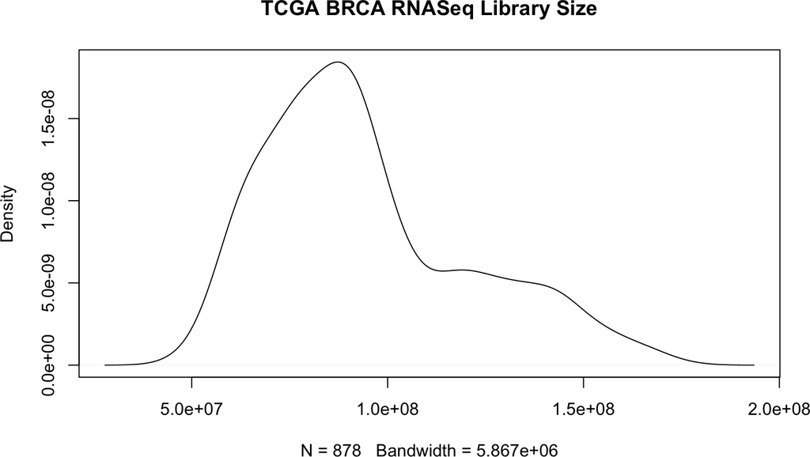

```r
mae[["BRCA_RNASeqGene-20160128"]] %>%
    assay() %>%
    colSums() %>%
    density() %>%
    plot(main = "TCGA BRCA RNASeq Library Size")
```

# 4 Annotating variants

## 4.1 VariantAnnotation

```r
library(VariantAnnotation)
```

## 4.2 ensemblVEP

```r
library(ensemblVEP)
```

# 5 Provenance